# Code sample for Jorge Luis Ochoa Rincón

Stanford Law School - **Standford University**

In this document you will find both code and output from the code. All code presented in the document comprises part of the analysis in my master thesis.

r

ggplot

statistics

TWFE

Econometrics

Author

Affiliation

[Jorge Ochoa](https://jorgeluis8ar.github.io)

[World Bank](https://www.worldbank.org/en/research/dime)

Published

December 11, 2023

This document presents both code in `R` and output produced for my master’s [**thesis**](https://dx.doi.org/10.2139/ssrn.4575115). Both [**spanish**](http://jorgeluis8ar.github.io/files/dcede2023-30.pdf) and [**english**](http://jorgeluis8ar.github.io/files/WP-Welfare-Effects-Subsidies-Case-Study-Public-Transport.pdf) versions are available. The document presents the results from the time reduction section of the paper. Code is not shown by default, but by clicking all code buttons, all code snippets appear on screen.

**Main results**

The following are the main results from the output. This results correspond only to reductions in time results. For the complete set of results please review the complete [**paper**](http://jorgeluis8ar.github.io/files/WP-Welfare-Effects-Subsidies-Case-Study-Public-Transport.pdf).

The following code cleans the environment, loads packages and data, process and sets up the data for the econometric analysis.

**Code: Environment, packages, data, and tidying**

```r
# Description ------------------------------------------------------------------

# Script: code_sample.R

# Author:: Jorge Luis Ochoa Rincon

# Date of creation: 2022-09-05
# Date las modification: 2022-09-05

# Objective:
# Load, process and set up data in order to estimate a TWFE dif-in-diff model. The
# script produces both tables and figures ready to be used in the final document

# Notes:
# No special character are used, except those needed.

# ---------------------------------------------------------------------------- #

# 0. Cleaning and setting up the environment -----------------------------------

cat("\f")                           # Cleaning the console
rm(list=ls())                       # Cleaning the environment
options("scipen"=100, "digits"=4)   # Number of digits for numeric values
Sys.setlocale("LC_TIME", "C")       # All dates in english format

# 1. Packages ------------------------------------------------------------------

if(!require('pacman')) install.packages('pacman')
pacman::p_load(anytime,lubridate,ggplot2,haven,tictoc,dlookr,report,viridis,readxl, gt,
               data.table,ggnewscale,dplyr,ggpubr,readr,sf,collapse,fixest,did,did2s, pander)

# 2. Directory  ----------------------------------------------------------------

# Personas computer
if (Sys.info()["user"] == "jorgeochoa") {
  onedrive <- "~/OneDrive - Universidad de los andes/PEG/Tesis/"
}else if (Sys.info()["user"] == "Other username") {
  onedrive <- "Directory"
}

setwd(onedrive)

# 2.1. Functions  --------------------------------------------------------------

source(paste0(onedrive,"Codigo/Funciones graficas.R"))

# 3. Data  ---------------------------------------------------------------------

df <- read_rds(paste0(onedrive,"Datos/Work/2022-09-04 Mode choice data frame/Panel decisiones seguimientos.RDS"))
df <- as.data.table(df)
df[TIPOC == "Control",tratamiento := 0]
df[TIPOC != "Control",tratamiento := 1]
df <- df[!is.na(act.1.modo.1),]

# data frame #2: Baseline data
source(paste0(onedrive,"Codigo/2023-01-02 - Tiempo de viaje/20230301_baseline_travel_time.R"))

df <- plyr::rbind.fill(df,lb)

# data frame #3: distances
distances <- read_sf(paste0(onedrive,"Datos/Raw/2022-11-01 - Distancias hogar/Min distance to BRT stop.shp"))
colnames(distances)[4] <- "min.dist.2.tm"

# data frame #4: Deposits
recargas <- read_rds(paste0(onedrive,"Datos/Raw/2022-09-07 - Recargas experimento/Recargas experimento 2021 completo.RDS"))
recargas <- as.data.table(recargas)

# data frame #5: data consolidation
consolidacion <- read_rds(paste0(onedrive,"Datos/Raw/2022-09-04 - Consolidacion/base de consolidacion emparejamiento de la informacion.RDS"))
consolidacion <- as.data.table(consolidacion)
colnames(consolidacion)[11] <- "id_tarjeta"

# data frame #6: Baseline
lb <- read_delim(paste0(onedrive,"Datos/Raw/2022-09-04 - Base encuesta linea base/Linea base corregida/Linea Base corregida.csv"))
lb <- as.data.table(lb)
lb[,mujer := (GENERO == "Femenino")]

# data frame #7: trips
validaciones <- read_delim(paste0(onedrive,"Datos/Raw/2022-09-07 - Validaciones experimento/Validaciones experimento 2021 completo.csv"))
validaciones <- as.data.table(validaciones)
validaciones[,indi.vali := 1]
validaciones <- merge(x = validaciones, y = consolidacion[,c("IDBASE","id_tarjeta")],by = c("id_tarjeta"),all.x = T)

validaciones.por.semana <- validaciones %>%
  fgroup_by(id_tarjeta,week) %>%
  fsummarise(vali.semana = fnobs(fecha_cl))

validaciones.por.semana <- merge(x = validaciones.por.semana,y = consolidacion[,c("IDBASE","id_tarjeta")],by = c("id_tarjeta"),all.x = T)

# 4. Data processing ---------------------------------------------------------

# Defining the panel structure
df <- df %>%
  mutate(alternativa = case_when(
    act.1.modo.1 %in% c("Cable","Transmilenio") ~ "Troncal",
    act.1.modo.1 %in% c("Alimentador","SITP - Urbano (azul, naranja, vinotinto)","SITP provisional","SITP - Urbano (azul, naranja, vino tinto)") ~ "Zonal",
    act.1.modo.1 %in% c("Autom?vil informal/pirata","Carro como conductor","Carro como pasajero","Taxi","Autom?vil particular- Uber, Beat","Mototaxi / Bicitaxi") ~ "Automovil",
    act.1.modo.1 %in% c("Bus intermunicipal","Bus privado/de empresa","Otro","Transporte escolar","Bus/buseta informal/pirata/Chana","Otro medio de transporte") ~ "Otro",
    act.1.modo.1 %in% c("Bicicleta","Patineta/ patines") ~ "Bicicleta",
    act.1.modo.1 %in% c("Motocicleta como conductor","Motocicleta como pasajero","Mototaxi") ~ "Motocicleta",
    act.1.modo.1 == "Caminando" ~ "Caminando"),
    semana.encuesta = case_when(
      SEMANA == "Semana 0" ~ 0,
      SEMANA == "Semana 1" ~ 1,
      SEMANA == "Semana 2" ~ 2,
      SEMANA == "Semana 3" ~ 3,
      SEMANA == "Semana 4" ~ 4,
      SEMANA == "Semana 5" ~ 5,
      SEMANA == "Semana 6" ~ 6,
      SEMANA == "Semana 7" ~ 7,
      SEMANA == "Semana 8" ~ 8,
      SEMANA == "Semana 9" ~ 9,
      SEMANA == "Semana 10" ~ 10,
      SEMANA == "Semana 11" ~ 11,
      SEMANA == "Semana 12" ~ 12,
      SEMANA == "Semana 13" ~ 13,
      SEMANA == "Semana 14" ~ 14,
      SEMANA == "Semana 15" ~ 15
    ))

# Treatment status
df <- as.data.table(df)
df[,mes := lubridate::month(date)]

recargas <- recargas[tipo_pago == "Subsidio para Universitario(13)",]
recargas <- recargas[!(valor == "100000"),]
recargas[,fecha_cl := as.Date(fecha_cl)]

df <- recargas %>%
  fgroup_by(id_tarjeta) %>%
  fsummarise(num.recargas = fnobs(fecha_cl),
             min.week = fmin(fecha_cl)) %>%
  fmutate(min.week = lubridate::week(min.week)) %>%
  merge(x = ., y = consolidacion[,c("IDBASE","id_tarjeta")], by = c("id_tarjeta"),all.x = T) %>%
  merge(x = ., y = df, by = c("IDBASE","id_tarjeta"), all.y = T)

df <- as.data.table(df)

df[,dif := abs(min.week-week)]
df[is.na(min.week), treated.group := 0]

df[, min.obs := which.min(dif), by = .(IDBASE)]

df <- df %>%
  filter(!is.na(min.week)) %>%
  group_by(IDBASE) %>%
  filter(abs(min.week - week) == min(abs(min.week - week))) %>%
  # select(IDBASE,semana.encuesta) %>%
  summarise(min.week.2 = min(semana.encuesta,na.rm = T)) %>%
  merge(x = ., y = df, by = c("IDBASE"), all.y = T)

df <- as.data.table(df)

df[!is.na(min.week), treated.group := min.week.2]
df[,tiempo.viaje := as.numeric(tiempo.viaje)]


df[,trat.rel := semana.encuesta - treated.group]
df[semana.encuesta == 0, trat.rel := semana.encuesta - min.week.2]
df[TIPOC == "Control",trat.rel := -1000]
df[,trat.rel.2 := trat.rel]
df[trat.rel.2 <= -5, trat.rel.2 := -5]
df[trat.rel.2 >= 10, trat.rel.2 := 10]
df[TIPOC == "Control", trat.rel.2 := -1000]

setorder(df, IDBASE,semana.encuesta)

df[trat.rel < 0, trat.tfwe := 0]
df[trat.rel >= 0, trat.tfwe := 1]

df <- df %>%
  mutate(costo.act1.2 = case_when(
    alternativa == "Automovil" ~ costo.act1,
    alternativa == "Bicicleta" ~ 0,
    alternativa == "Caminando" ~ 0,
    alternativa == "Motocicleta" ~ costo.act1,
    alternativa == "Otro" ~ costo.act1,
    alternativa == "Troncal" ~ 2500,
    alternativa == "Zonal" ~ 2300
  ))

df <- as.data.table(df)

df$num.modos.usados <- apply(df[,c(24:29)], 1, function(x) sum(!is.na(x)))

vector.modos <- c()
for (observa in 1:nrow(df)) {

  vector.modos[observa] <- sum(!(apply(df[observa,c(24:29)], 1, function(x) unique(x)) %>% unlist() %>% is.na()) %>% as.vector())

}

df$nummodos.dist.usados <- vector.modos

df[,dayofweek := lubridate::wday(date,label = TRUE,abbr = FALSE)]

df[, precio.mean := mean(costo.act1.2,na.rm = T), by = .(alternativa)]
df[is.na(costo.act1.2), costo.act1.2 := precio.mean]


df[, motivo2:= case_when(motivo.modo.1 %in% c("Trabajar / Asuntos de trabajo") ~ "Trabajar",
                         !(motivo.modo.1 %in% c("Trabajar / Asuntos de trabajo")) ~ "Resto")]

df <- merge(x = df,y = lb[,c("IDBASE","mujer")], by = c("IDBASE"),all.x = T)
df <- merge(x = df,y = validaciones.por.semana, by = c("IDBASE","id_tarjeta","week"),all.x = T)
df[,tratados := !is.na(min.week.2)]

# Difference in means test
# t.test(tiempo.viaje ~ trat.tfwe,data = df[!(TIPOC == "Control")])
# t.test(tiempo.viaje ~ trat.tfwe,data = df[!(TIPOC == "Tratamiento 1")])
# t.test(tiempo.viaje ~ trat.tfwe,data = df[!(TIPOC == "Tratamiento 2")])

df[,trata := TIPOC == "Tratamiento 1"]
df[,tratb := TIPOC == "Tratamiento 2"]

df <- merge(x = df, y = st_drop_geometry(distances[,c("IDBASE","min.dist.2.tm")]), by = c("IDBASE"), all.x = T)
df <- as.data.table(df)
df[,rownum := rowid(IDBASE)]

df[, post:=trat.tfwe]
df[(TIPOC == "Control")&(week > 18), post := 1]
df[(TIPOC == "Control")&(week <= 18), post := 0]

df[, post2 := NA]
df[(week > 18), post2 := 1]
df[(week <= 18), post2 := 0]

df[(IDBASE == "266")&(week == 22), hora.llegada.act.1 := hora.llegada.act.1 + days(1)]
df[(IDBASE == "266")&(week == 23), hora.llegada.act.1 := hora.llegada.act.1 + days(1)]
df[(IDBASE == "738")&(week == 20), hora.llegada.act.1 := hora.llegada.act.1 + days(1)]
df[(IDBASE == "1206")&(week == 28), hora.llegada.act.1 := hora.llegada.act.1 + hours(12)]
df[(IDBASE == "1565")&(week == 32), hora.llegada.act.1 := hora.llegada.act.1 + days(1)]
df[(IDBASE == "1770")&(week == 31), hora.llegada.act.1 := hora.llegada.act.1 + hours(12)]
df[(IDBASE == "2512")&(week == 23), hora.llegada.act.1 := hora.llegada.act.1 + hours(12)]
df[(IDBASE == "4849")&(week == 23), hora.llegada.act.1 := hora.llegada.act.1 + hours(12)]
df[(IDBASE == "4895")&(week == 23), hora.llegada.act.1 := hora.llegada.act.1 + days(1)]
df[(IDBASE == "5224")&(week == 21), hora.llegada.act.1 := hora.llegada.act.1 + hours(12)]
df[(IDBASE == "8504")&(week == 23), hora.llegada.act.1 := hora.llegada.act.1 + days(1)]
df[(IDBASE == "12246")&(week == 28), hora.llegada.act.1 := hora.llegada.act.1 + hours(12)]
df[(IDBASE == "14805")&(week == 31), hora.llegada.act.1 := hora.llegada.act.1 + hours(12)]
df[(IDBASE == "16105")&(week == 36), hora.llegada.act.1 := hora.llegada.act.1 + hours(12)]
df[(IDBASE == "14805")&(week == 25), hora.llegada.act.1 := hora.llegada.act.1 + hours(12)]
df[(IDBASE == "16105")&(week == 27), hora.llegada.act.1 := hora.llegada.act.1 + hours(12)]
df[(IDBASE == "17385")&(week == 36), hora.llegada.act.1 := hora.llegada.act.1 + hours(12)]
df[(IDBASE == "17594")&(week == 20), hora.llegada.act.1 := hora.llegada.act.1 + hours(12)]
df[(IDBASE == "17734")&(week == 28), hora.llegada.act.1 := hora.llegada.act.1 + hours(12)]
df[(IDBASE == "17778")&(week == 23), hora.llegada.act.1 := hora.llegada.act.1 + days(1)]
df[(IDBASE == "17905")&(week == 36), hora.llegada.act.1 := hora.llegada.act.1 + hours(12)]
df[(IDBASE == "17980")&(week == 25), hora.llegada.act.1 := hora.llegada.act.1 + hours(12)]
df[(IDBASE == "17980")&(week == 28), hora.llegada.act.1 := hora.llegada.act.1 + hours(12)]
df[(IDBASE == "21667")&(week == 25), hora.llegada.act.1 := hora.llegada.act.1 + hours(12)]
df[(IDBASE == "25642")&(week == 27), hora.llegada.act.1 := hora.llegada.act.1 + hours(12)]
```

# Results

This section is divided in two sections. First, I explore the program ATT using a TWFE model. Here I want determine the average effect of the treatment on the treated, The second section uses an event study approach. Here, I wish to report treatment effects by treatment exposure.

## Static TWFE model

**Result: Effect of transport subsidies on travel time**

```r
df[,`Participant` := IDBASE]
df[,`Time` := semana.encuesta]

# Static twfe: Recovering the ATT sin controles
twfe.att <- feols(tiempo.viaje ~ i(trat.tfwe,tratamiento,ref = 0,ref2 = 0)|`Time` + `Participant`, data = df,vcov = ~ `Participant` + `Time`)
twfe.att.trat <- feols(tiempo.viaje ~ i(trat.tfwe,TIPOC,ref = 0,ref2 = "Control") |`Time` + `Participant`, data = df,vcov = ~ `Participant` + `Time`)

# Static twfe: Recovering the ATT con controles
twfe.att.contr <- feols(tiempo.viaje ~ i(trat.tfwe,tratamiento,ref = 0,ref2 = 0) + costo.act1.2 + i(dayofweek,ref = "Monday") + i(alternativa,ref = "Caminando") |`Time` + `Participant`, data = df,vcov = ~ `Participant` + `Time`)
twfe.att.contr.trat <- feols(tiempo.viaje ~ i(trat.tfwe,TIPOC,ref = 0,ref2 = "Control") + costo.act1.2 + i(dayofweek,ref = "Monday") + i(alternativa,ref = "Caminando") |`Time` + `Participant`, data = df,vcov = ~ `Participant` + `Time`)

mydict <- c("trat.tfwe::1:tratamiento" = "Treatment",
            "trat.tfwe::1:TIPOC::Tratamiento 1" = "Treatment A",
            "trat.tfwe::1:TIPOC::Tratamiento 2" = "Treatment B")

function.fixest.2.gt <- function(fixest.object){
df.coefss <- fixest.object$coeftable
rownames.vec <- rownames(df.coefss)
df.coefss <- as.data.frame(df.coefss)
colnames(df.coefss) <- c("estimate","se","t","p")
df.coefss <- as.data.table(df.coefss)
df.coefss[,coeff := rownames.vec]
df.coefss <- df.coefss[grepl("trat.tfwe",df.coefss$coeff)]
df.coefss[,coeff := mydict[coeff]]
df.coefss[,stars := case_when(p <= 0.01 ~ "***",
                              p <= 0.05 ~ "**",
                              p <= 0.1 ~ "*",
                              p > 0.1 ~ "")]
df.coefss[,value := paste0(round(estimate,3),stars," (",round(se,4),")")]
df.object <- dplyr::bind_rows(df.coefss[,c("coeff","value")],
                              data.frame(coeff = "Time Fixed Effects", value = "Yes"),
                              data.frame(coeff = "Participant Fixed Effects", value = "Yes"),
                              data.frame(coeff = "Controls", value = "Yes"),
                              data.frame(coeff = "S.E.: Clustered", value = "Time & Participant"),
                              data.frame(coeff = "Observations", value = as.character(round(fixest.object$nobs,0))),
                              data.frame(coeff = "R2", value = as.character(round(r2(fixest.object, "r2"),4))))
df.object <- as.data.table(df.object)
df.object[,index := 1:nrow(df.object)]
return(df.object)
}

df.gt1 <- cbind(function.fixest.2.gt(fixest.object = twfe.att),
                function.fixest.2.gt(fixest.object = twfe.att.contr))
df.gt1 <- df.gt1[,c(1,2,3,5)]
df.gt1 <- as.data.table(df.gt1)
df.gt1[index == 1, index := 0]
colnames(df.gt1) <- c("coef","value","index","value2")

df.gt2 <- cbind(function.fixest.2.gt(fixest.object = twfe.att.trat),
                function.fixest.2.gt(fixest.object = twfe.att.contr.trat))
df.gt2 <- df.gt2[,c(1,2,3,5)]
df.gt2 <- as.data.table(df.gt2)
colnames(df.gt2) <- c("coef","value3","index2","value4")

df.gt <- merge(x = df.gt1,y = df.gt2,by = c("coef"),all = T)
df.gt <- as.data.table(df.gt)
df.gt[,ind := ifelse(is.na(index2),index,index2)]
setorder(df.gt,ind)
df.gt <- df.gt[,-c("index","ind","index2")]
df.gt[is.na(value),  value  := ""]
df.gt[is.na(value2), value2 := ""]
df.gt[is.na(value3), value3 := ""]
df.gt[is.na(value4), value4 := ""]

df.gt[coef == "Controls", value := "No"]
df.gt[coef == "Controls", value2 := "Yes"]
df.gt[coef == "Controls", value3 := "No"]
df.gt[coef == "Controls", value4 := "Yes"]

df.gt %>%
  gt() %>%
  tab_stubhead(label = "Orbis Outcome") %>%
  tab_spanner(label = md("**Dependent variable**: *Travel time*"),columns = 2:5,level = 3) %>%
  tab_spanner(label = md("***Sample***"),columns = 2:5,level = 2) %>%
  tab_spanner(label = md("**Assignment to treatment**"),columns = 2:3,level = 1) %>%
  tab_spanner(label = md("**Treatment Assignment**"),columns = 4:5,level = 1) %>%
  cols_label(coef = html(""),
             value = html("Travel time<br>(1)"),
             value2 = html("Travel time<br>(2)"),
             value3 = html("Travel time<br>(3)"),
             value4 = html("Travel time<br>(4)"),) %>%
  tab_header(title = md("**Number of Bankruptcy cases per state**")) %>%
  tab_source_note(source_note = md("**Note**: This table presents results of a TWFE model. All regressions were estimated using function **{feols}** using the R package **{fixest}**.\nTreatment variable estimates represent the average effect on those treated. The dependent variable in all columns is the travel time reported for each trip in the follow-up surveys. Travel time represents the aggregation of 1) travel time to the mode of transportation, 2) waiting time, and 3) commuting time. In columns 1 and 2, the treatment variable is equal to one in the follow-up survey that used the conditional treatment to be previously assigned to the treatment group, zero otherwise. On the other hand, in columns 3 and 4 the treatment variables are equal to one in the follow-up survey conditional on the amount of the subsidy to which they were chosen, zero otherwise. Columns 2 and 4 present estimates using the vector of controls *X*_{ie}. The control variables included are total commuting cost, day of the week indicator, and mode of transportation used indicator. Clustered standard errors by person and follow-up survey number are presented in parentheses.")) %>%
  tab_source_note(source_note = md("**Signficance level**: \\*\\*\\*1%,\\*\\* 5%, \\*10%")) %>%
  cols_align(align = "center",columns = !coef) %>%
  cols_align(align = "left",columns = coef) %>%
  tab_style_body(fn = function(x) stringr::str_detect(string = x,pattern = "\\*"),
                 style = cell_text(color = 'black', weight = 'bold')) %>%
  opt_stylize(style = 1, color = 'gray')
```

Table 1: Effect of transport subsidies on travel times

|  | **Dependent variable**: *Travel time* **Sample** **Assignment to treatment** Travel time (1) | **Dependent variable**: *Travel time* **Sample** **Assignment to treatment** Travel time (2) | **Dependent variable**: *Travel time* **Sample** **Treatment Assignment** Travel time (3) | **Dependent variable**: *Travel time* **Sample** **Treatment Assignment** Travel time (4) |
| --- | --- | --- | --- | --- |
| Treatment | -10.191** (3.6796) | -10.469** (3.9004) |  |  |
| Treatment A |  |  | -19.562** (7.5124) | -18.794** (7.595) |
| Treatment B |  |  | -1 (4.0208) | -2.296 (4.359) |
| Time Fixed Effects | Yes | Yes | Yes | Yes |
| Participant Fixed Effects | Yes | Yes | Yes | Yes |
| Controls | No | Yes | No | Yes |
| S.E.: Clustered | Time & Participant | Time & Participant | Time & Participant | Time & Participant |
| Observations | 14610 | 14547 | 14610 | 14547 |
| R2 | 0.2077 | 0.2187 | 0.2081 | 0.2191 |

**Note**: This table presents results of a TWFE model. All regressions were estimated using function **{feols}** using the R package **{fixest}**. Treatment variable estimates represent the average effect on those treated. The dependent variable in all columns is the travel time reported for each trip in the follow-up surveys. Travel time represents the aggregation of 1) travel time to the mode of transportation, 2) waiting time, and 3) commuting time. In columns 1 and 2, the treatment variable is equal to one in the follow-up survey that used the conditional treatment to be previously assigned to the treatment group, zero otherwise. On the other hand, in columns 3 and 4 the treatment variables are equal to one in the follow-up survey conditional on the amount of the subsidy to which they were chosen, zero otherwise. Columns 2 and 4 present estimates using the vector of controls *X*_{ie}. The control variables included are total commuting cost, day of the week indicator, and mode of transportation used indicator. Clustered standard errors by person and follow-up survey number are presented in parentheses.  
**Signficance level**: ***1%,** 5%, *10%

## Event study

**Result: Effect of transport subsidies on travel times by length of exposure**

```r
trat.rel <- feols(tiempo.viaje ~ i(trat.rel.2,trata,ref = c(-1,-1000),FALSE) +  i(trat.rel.2,tratb,ref = -1,FALSE) + costo.act1.2 + i(dayofweek,ref = "Monday") + i(alternativa,ref = "Caminando")|semana.encuesta + IDBASE,data = df, vcov = ~semana.encuesta + IDBASE)


df.coef.joint <- trat.rel$coeftable %>% as.data.frame()
df.coef.joint <- df.coef.joint[grep("trat.rel", rownames(df.coef.joint)),]
df.coef.joint$name <- rownames(df.coef.joint)
df.coef.joint <- as.data.table(df.coef.joint)
colnames(df.coef.joint) <- c("estimate","se","t","pval","name")
df.coef.joint <- plyr::rbind.fill(df.coef.joint,data.frame(estimate = 0,se = 0, t = 0, pval = 0, name = c("-1:trata","-1:tratb")))
df.coef.joint <- as.data.table(df.coef.joint)

df.coef.joint[grep("trata",name),treatment := "Tratamiento A"]
df.coef.joint[grep("tratb",name),treatment := "Tratamiento B"]

df.coef.joint[,period := name]
df.coef.joint[,period := stringr::str_replace_all(period,"trat.rel.2::"," ")]
df.coef.joint[,period := stringr::str_replace_all(period,"trata"," ")]
df.coef.joint[,period := stringr::str_replace_all(period,"tratb"," ")]
df.coef.joint[,period := stringr::str_replace_all(period,":"," ")]
df.coef.joint[,period := as.numeric(period)]

df.coef.joint[,min.val := estimate - 1.96*se]
df.coef.joint[,max.val := estimate + 1.96*se]

colors.cs.plot <- c("Tratamiento A" = "#8a0101","Tratamiento B" = "#707070")

# Event Study: Treatment groups

es.english.treat.groups <- ggplot(data = df.coef.joint) +
  geom_vline(xintercept = -1,linetype = "dashed") +
  geom_hline(yintercept = 0) +
  geom_line(aes(x = period, y = estimate, group = treatment), position = position_dodge(width = 0.9)) +
  geom_errorbar(aes(x = period,y = estimate,ymin = min.val, ymax = max.val, color = treatment), position = position_dodge2(width = 0.6)) +
  geom_point(aes(x = period,y = estimate, fill = treatment, shape = treatment,color = treatment), position = position_dodge(width = 0.9), size = 4) +
  scale_color_manual(values = colors.cs.plot, labels = c("Treatment A: $COP28,000","Treatment B: $COP21,000")) +
  scale_fill_manual(values = colors.cs.plot, labels = c("Treatment A: $COP28,000","Treatment B: $COP21,000")) +
  scale_shape_manual(values = c("Tratamiento A" = 21,"Tratamiento B" = 22),labels = c("Treatment A: $COP28,000","Treatment B: $COP21,000")) +
  labs(x = "\nSurveys to treatment", y = "Coefficient",
       fill = "Treatment", color = "Treatment", shape = "Treatment") +
  scale_x_continuous(breaks = seq(-5,10,1)) +
  scale_y_continuous(breaks = seq(-80,80,20)) +
  theme_classic() +
  theme(legend.position = c(0.8,0.85),
        axis.text = element_text(color = "black", size = 17),
        axis.title = element_text(color = "black", size = 19),
        legend.title = element_text(color = "black", size = 19),
        legend.text = element_text(color = "black", size = 17),
        legend.background = element_blank(),
        axis.text.x = element_text(hjust = 0.5,vjust = 0.5))

twfe.2.contr <- feols(tiempo.viaje ~ i(trat.rel.2,tratamiento,ref = c(-1,-1000)) + costo.act1.2 + i(dayofweek,ref = "Monday") + i(alternativa,ref = "Caminando")|semana.encuesta + IDBASE,data = df, vcov = ~semana.encuesta + IDBASE)

df.coef.joint <- twfe.2.contr$coeftable %>% as.data.frame()
df.coef.joint <- df.coef.joint[grep("trat.rel", rownames(df.coef.joint)),]
df.coef.joint$name <- rownames(df.coef.joint)
df.coef.joint <- as.data.table(df.coef.joint)
colnames(df.coef.joint) <- c("estimate","se","t","pval","name")
df.coef.joint <- plyr::rbind.fill(df.coef.joint,data.frame(estimate = 0,se = 0, t = 0, pval = 0, name = c("-1:tratamiento")))
df.coef.joint <- as.data.table(df.coef.joint)

df.coef.joint[grep("trata",name),treatment := "Tratamiento"]

df.coef.joint[,period := name]
df.coef.joint[,period := stringr::str_replace_all(period,"trat.rel.2::"," ")]
df.coef.joint[,period := stringr::str_replace_all(period,"tratamiento"," ")]
df.coef.joint[,period := stringr::str_replace_all(period,":"," ")]
df.coef.joint[,period := as.numeric(period)]

df.coef.joint[,min.val := estimate - 1.96*se]
df.coef.joint[,max.val := estimate + 1.96*se]

es.englist.treatment <- ggplot(data = df.coef.joint) +
  geom_vline(xintercept = -1.0,linetype = "dashed") +
  geom_hline(yintercept = 0,linetype = 3) +
  geom_line(aes(x = period, y = estimate, group = treatment), position = position_dodge(width = 0.9)) +
  geom_errorbar(aes(x = period,y = estimate,ymin = min.val, ymax = max.val),color = "black", width = 0.3) +
  geom_point(aes(x = period,y = estimate),size = 4, color = "black", fill = "black", shape = 21) +
  labs(x = "\nSurveys to treatment", y = "Coefficient") +
  scale_x_continuous(breaks = seq(-5,10,1)) +
  scale_y_continuous(breaks = seq(-80,80,20)) +
  theme_classic() +
  theme(legend.position = c(0.9,0.85),
        axis.text = element_text(color = "black", size = 17),
        axis.title = element_text(color = "black", size = 19),
        legend.title = element_text(color = "black", size = 19),
        legend.text = element_text(color = "black", size = 17),
        legend.background = element_blank(),
        axis.text.x = element_text(hjust = 0.5,vjust = 0.5))
```

**Complete sample**

**Result: Complete sample**

Figure 1: Effect of transport subsidies on travel times by length of exposure - Complete sample

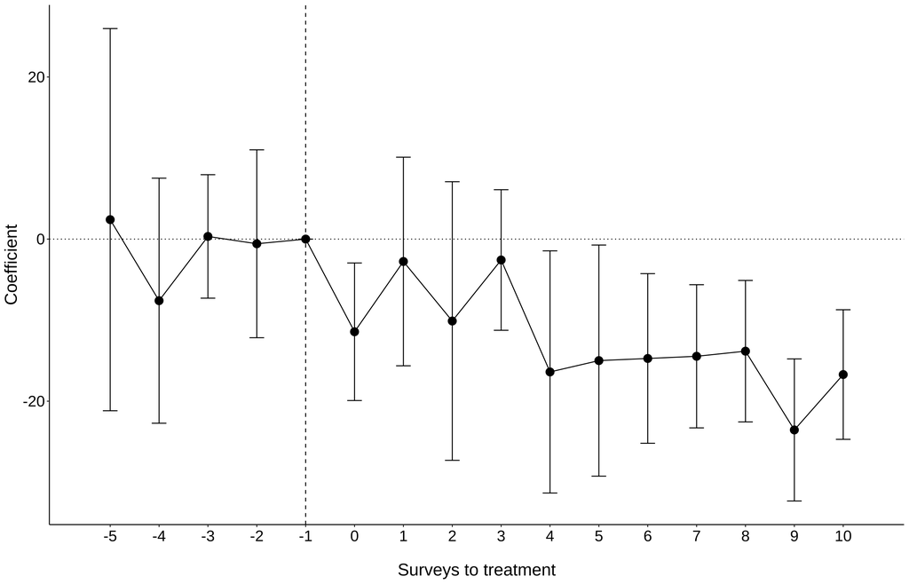

```r
es.englist.treatment
```

**Treatment Groups**

**Result: Treatment Group**

Figure 2: Effect of transport subsidies on travel times by length of exposure - Treament Groups

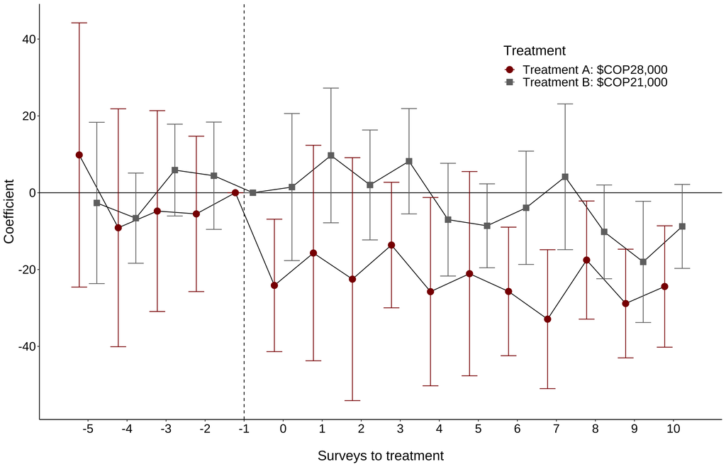

```r
es.english.treat.groups
```

## Citation

BibTeX citation:

```
@online{ochoa2023,
  author = {Ochoa, Jorge},
  title = {Code Sample for {Jorge} {Luis} {Ochoa} {Rincón}},
  date = {2023-12-11},
  langid = {en}
}
```

For attribution, please cite this work as:

Ochoa, Jorge. 2023. “Code Sample for Jorge Luis Ochoa Rincón.” December 11, 2023.

Document made by [Jorge L. Ochoa Rincón](https://jorgeluis8ar.github.io/)

*jl.ochoa@uniandes.edu.co*